# Epidemic curves

## Overview

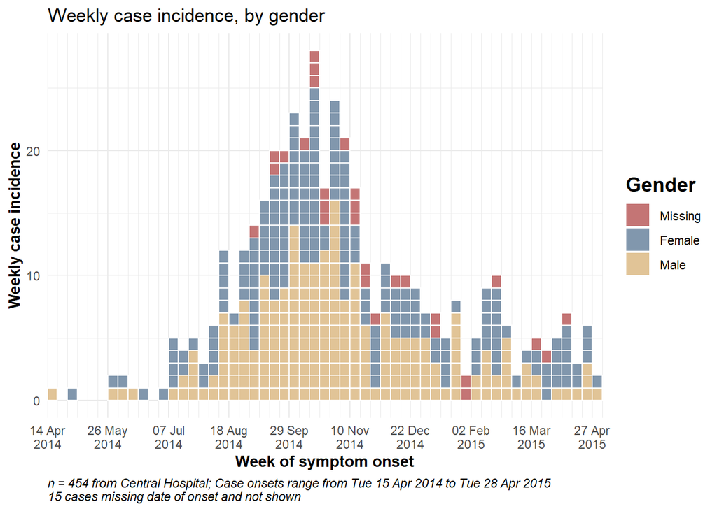

## Preparation

### Packages

This code chunk shows the loading of packages required for the analyses.

```r
pacman::p_load(rio,          # File import
               here,         # File locator
               lubridate,    # working with  dates
               aweek,        # alternative package for working with dates
               incidence,    # an option for epicurves of linelist data
               stringr,      # Search and manipulate character strings
               forcats,      # working with factors
               RColorBrewer, # Color palettes from colorbrewer2.org
               tidyverse,    # data management + ggplot2 graphics
)
```

```
##
## Your package installed
```

### Load data

Two example datasets are used in this section:

- Linelist of individual cases from a simulated epidemic
- Aggregated counts by hospital from the same simulated epidemic

The dataset is imported using the `import()` function from the *rio* package. See the *page on importing data* for various ways to import data. The linelist and aggregated versions of the data are displayed below.

For most of this document, the *linelist dataset* will be used. The aggregated counts dataset will be used at the end.

```r
# fake import the linelist
linelist <- rio::import("linelist_cleaned.xlsx")
```

Review the two datasets and notice the differences

**Case linelist**

The first 50 rows are displayed

| case_id | generation | date_infection | date_onset | date_hospitalisation | date_outcome | outcome | gender | age | age_unit | age_years | age_cat | age_cat5 | hospital | lon | lat | infector | source | wt_kg | ht_cm | ct_blood | fever | chills | cough | aches | vomit | temp | time_admission | days_onset_hosp |
| --- | --- | --- | --- | --- | --- | --- | --- | --- | --- | --- | --- | --- | --- | --- | --- | --- | --- | --- | --- | --- | --- | --- | --- | --- | --- | --- | --- | --- |
| 20b688 | 3 |  | 2014-04-15 | 2014-05-06 | 2014-05-14 | Death | m | 14 | years | 14 | 10-14 | 10-14 | Central Hospital | -13.2330769474001 | 8.46002984141364 |  |  | 57.9543370750053 | 166.749418687763 | 21 | no | no | no | no | no | 36.2840110708362 |  | 21 |
| a3c8b8 | 4 | 2014-05-07 | 2014-05-08 | 2014-05-10 | 2014-05-14 | Recover | m | 12 | years | 12 | 10-14 | 10-14 | Port Hospital | -13.2231931914572 | 8.47325128269697 | 2ae019 | other | 72.903315711843 | 133.818602320123 | 22 | no | no | yes | no | no | 37.4817129799808 | 12:25 | 2 |
| 72b905 | 4 | 2014-05-06 | 2014-05-12 | 2014-05-13 |  | Recover | m | 26 | years | 26 | 20-29 | 25-29 | Other | -13.2122631729853 | 8.46838441895748 | 2ae019 | other | 61.3550373807362 | 151.695755303934 | 21 |  |  |  |  |  | 37.1331561923118 |  | 1 |
| 8689b7 | 4 |  | 2014-05-13 | 2014-05-14 | 2014-05-18 | Recover | f | 25 | years | 25 | 20-29 | 25-29 | Missing | -13.2152339775486 | 8.45171855856465 |  |  | 74.9252154987378 | 153.316319514732 | 23 | no | no | yes | no | no | 36.5729378731705 | 13:23 | 1 |
| 11f8ea | 2 |  | 2014-05-16 | 2014-05-18 | 2014-05-30 | Recover | m | 18 | years | 18 | 15-19 | 15-19 | St. Mark's Maternity Hospital (SMMH) | -13.212910703914 | 8.46481700596819 |  |  | 60.8140332121575 | 165.290650391993 | 22 | no | yes | yes | no | no | 36.6132940820539 | 19:49 | 2 |
| 893f25 | 3 | 2014-05-18 | 2014-05-21 | 2014-05-22 | 2014-05-29 | Recover | m | 22 | years | 22 | 20-29 | 20-24 | Military Hospital | -13.2228638912441 | 8.46082377490923 | 11f8ea | other | 73.0392927197671 | 120.122123158907 | 21 | no | no | yes | no | yes | 36.9562671678823 | 15:31 | 1 |
| c4e706 | 5 |  |  | 2014-05-24 | 2014-06-02 |  | m | 6 | years | 6 | 5-9 | 5-9 | Missing | -13.2143394209926 | 8.48932072596067 |  |  | 40.3952926046292 | 108.261883736877 | 21 |  |  |  |  |  | 36.8447226634927 | 13:10 |  |
| e02f66 | 4 | 2014-05-18 |  | 2014-05-25 | 2014-05-31 |  | f | 1 | years | 1 | 0-4 | 0-4 | Port Hospital | -13.2599196027204 | 8.45436259178895 | bd8c0e | other | 18.5860458051297 | 47.4422250141074 | 23 | no | no | yes | no | yes | 37.2397852010363 | 14:27 |  |
| ce9c02 | 5 | 2014-05-27 | 2014-05-27 | 2014-05-29 | 2014-06-17 | Death | m | 13 | years | 13 | 10-14 | 10-14 | Port Hospital | -13.2243703238737 | 8.47024789713924 | 53da57 | other | 65.915405266829 | 166.387318202026 | 22 | no | yes | yes | no | no | 37.2266736491902 | 20:43 | 2 |
| 56d39e | 5 |  | 2014-05-27 | 2014-05-28 |  | Death | f | 27 | years | 27 | 20-29 | 25-29 | St. Mark's Maternity Hospital (SMMH) | -13.2115157489446 | 8.45094401624318 |  |  | 59.7407289858923 | 156.775506829027 | 22 | no | no | no | no | no | 37.2344022830661 | 15:55 | 1 |

[output cut: 40 more lines]

**Case counts aggregated by hospital**

The first 50 rows are displayed

| hospital | date_hospitalisation | n_cases |
| --- | --- | --- |
| Central Hospital | 2014-05-06 | 1 |
| Central Hospital | 2014-05-10 | 1 |
| Central Hospital | 2014-05-13 | 1 |
| Central Hospital | 2014-05-28 | 2 |
| Central Hospital | 2014-06-06 | 1 |
| Central Hospital | 2014-06-09 | 1 |
| Central Hospital | 2014-06-14 | 1 |
| Central Hospital | 2014-06-19 | 1 |
| Central Hospital | 2014-07-09 | 1 |
| Central Hospital | 2014-07-10 | 1 |

[output cut: 40 more lines]

### Set parameters

You may want to set certain parameters for production of a report, such as the date for which the data is current (the “data date”). You can then reference the `data_date` in the code when applying filters or in captions that auto-update.

```r
## set the report date for the report
## note: can be set to Sys.Date() for the current date
data_date <- as.Date("2015-05-15")
```

### Verify dates

Verify that each relevant date column is class Date and has an appropriate range of values. This `for` loop prints a histogram for each column.

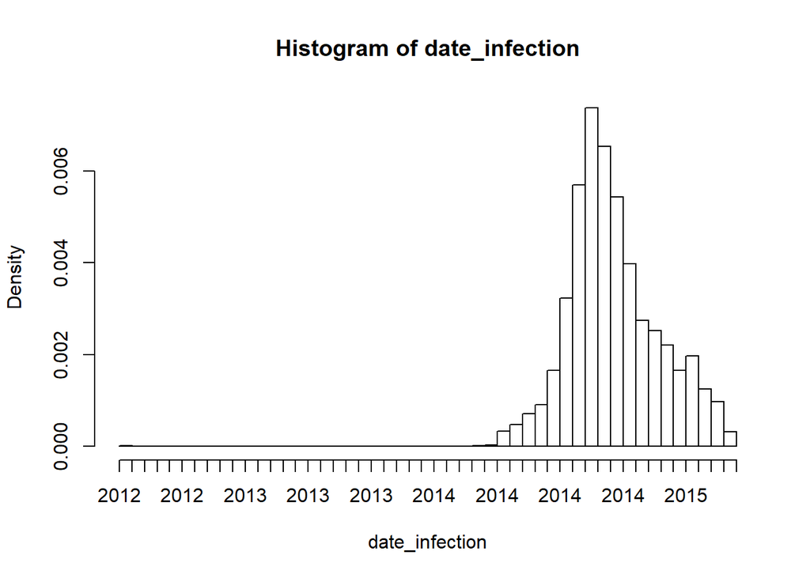

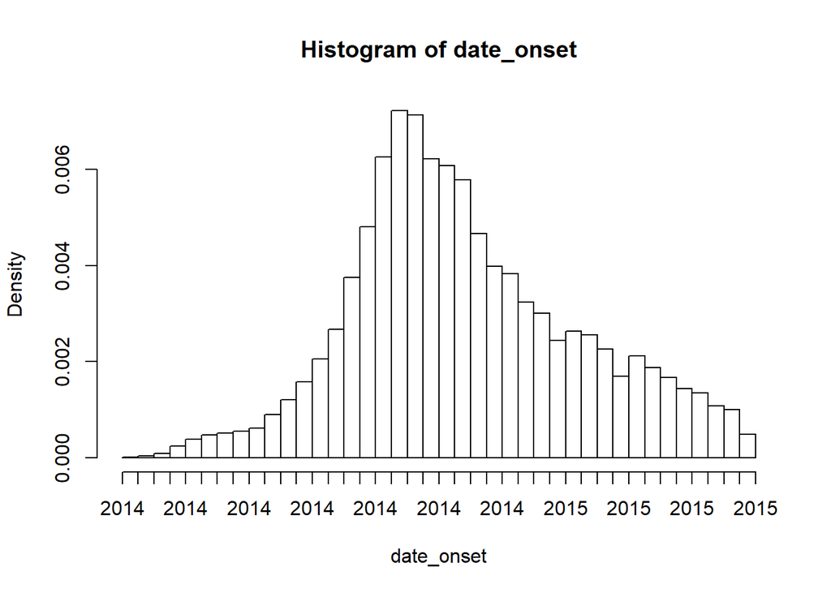

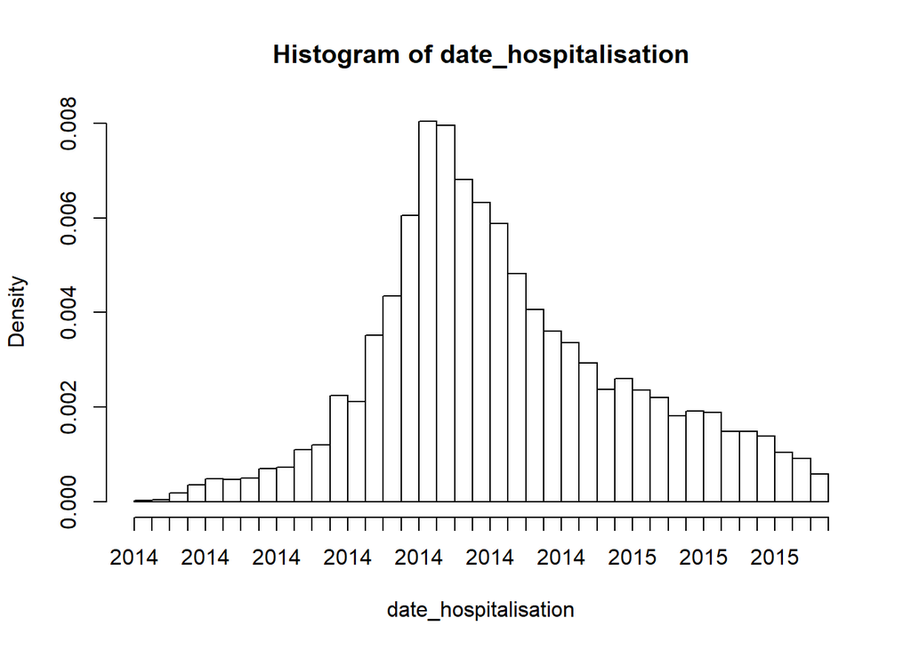

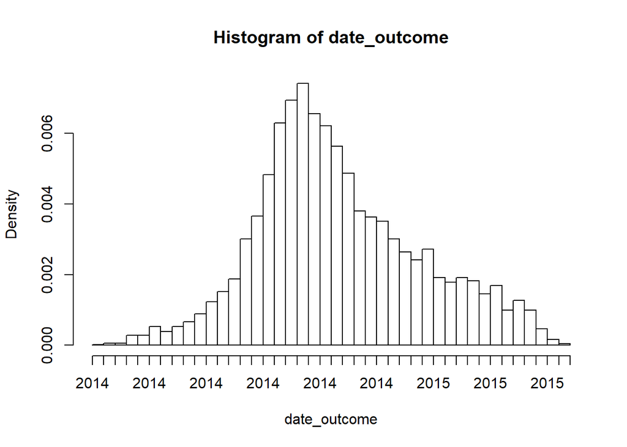

```r
# create character vector of column names
DateCols <- as.character(tidyselect::vars_select(names(linelist), matches("date|Date|dt")))

# Produce histogram of each date column
for (Col in DateCols) {     # open loop. iterate for each name in vector DateCols
  hist(linelist[, Col],     # print histogram of the column in linelist dataframe
       breaks = 50,         # number of breaks for the histogram
       xlab = Col)          # x-axis label is the name of the column
  }                         # close the loop
```

## `incidence` package

Below are tabs on making quick epicurves using the **incidence** package

*CAUTION:* Epicontacts expects data to be in a “linelist” format of one row per case (not aggregated). If your data is aggregated counts, look to the ggplot epicurves tab.

*TIP:* The documentation for plotting an **incidence** object can be accessed by entering `?plot.incidence` in your R console.

https://cran.r-project.org/web/packages/incidence/vignettes/customize_plot.html#example-data-simulated-ebola-outbreak

### Intro

**2 steps are requires to plot an epicurve with the *incidence* package:**

1. **Create** an *incidence object* (using the function `incidence()`)
   - Provide the case linelist
   - Specify the *time interval* into which the cases should be aggregated (daily, weekly, monthly..)
   - Specify any sub-groups
2. **Plot** the incidence object
   - Specify labels, aesthetic themes, etc.

**A simple example** - an epicurve of daily cases:

```r
# load incidence package
library(incidence)

# create the incidence object using data by day
epi_day   <- incidence(linelist$date_onset,  # the linelist data
                       interval = "day")     # the time interval
```

```
## 248 missing observations were removed.
```

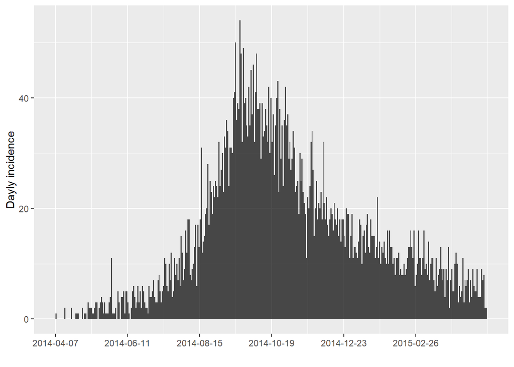

```r
# plot the incidence object
plot(epi_day)
```

**Change time interval of case aggregation (bars)**

The `interval` argument defines how the observations are grouped. Available options include all the options from the package **aweek**, including but not limited to:

- “week” (Monday start day is default)
- “2 weeks” (or 3, 4, 5…)
- “Sunday week”
- “2 Sunday weeks” (or 3, 4, 5…)
- “MMWRweek” (starts on Sunday - see US CDC)
- “month” (1st of month)
- “quarter” (1st of month of quarter)
- “2 months” (or 3, 4, 5…)
- “year” (1st day of calendar year)

Below are examples of how different intervals look when applied to the linelist.  
Format and frequency of the date *labels* on the x-axis are the defaults for the specified interval.

```r
# Create the incidence objects (with different intervals)
##############################
# Weekly (Monday week by default)
epi_wk      <- incidence(linelist$date_onset, interval = "Monday week")
```

```
## 248 missing observations were removed.
```

```r
# Sunday week
epi_Sun_wk  <- incidence(linelist$date_onset, interval = "Sunday week")
```

```
## 248 missing observations were removed.
```

```r
# Three weeks (Monday weeks by default)
epi_3wk     <- incidence(linelist$date_onset, interval = "3 weeks")
```

```
## 248 missing observations were removed.
```

```r
# Monthly
epi_month   <- incidence(linelist$date_onset, interval = "month")
```

```
## 248 missing observations were removed.
```

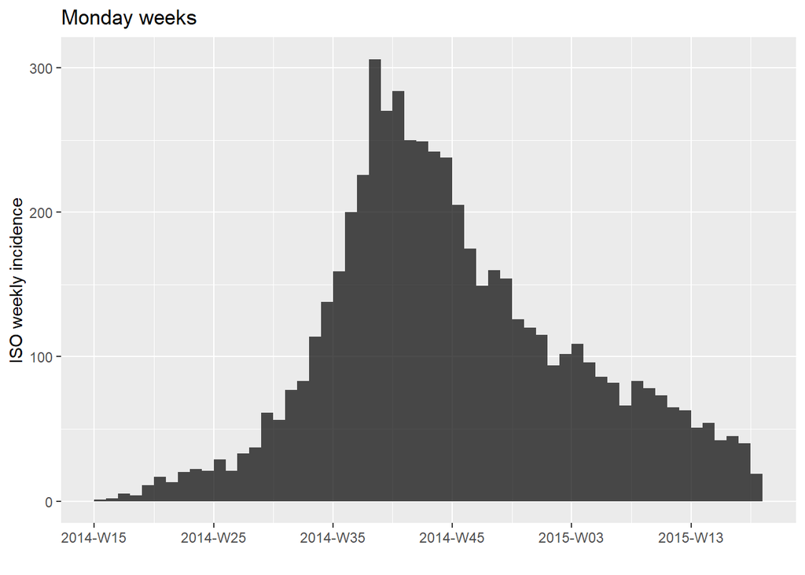

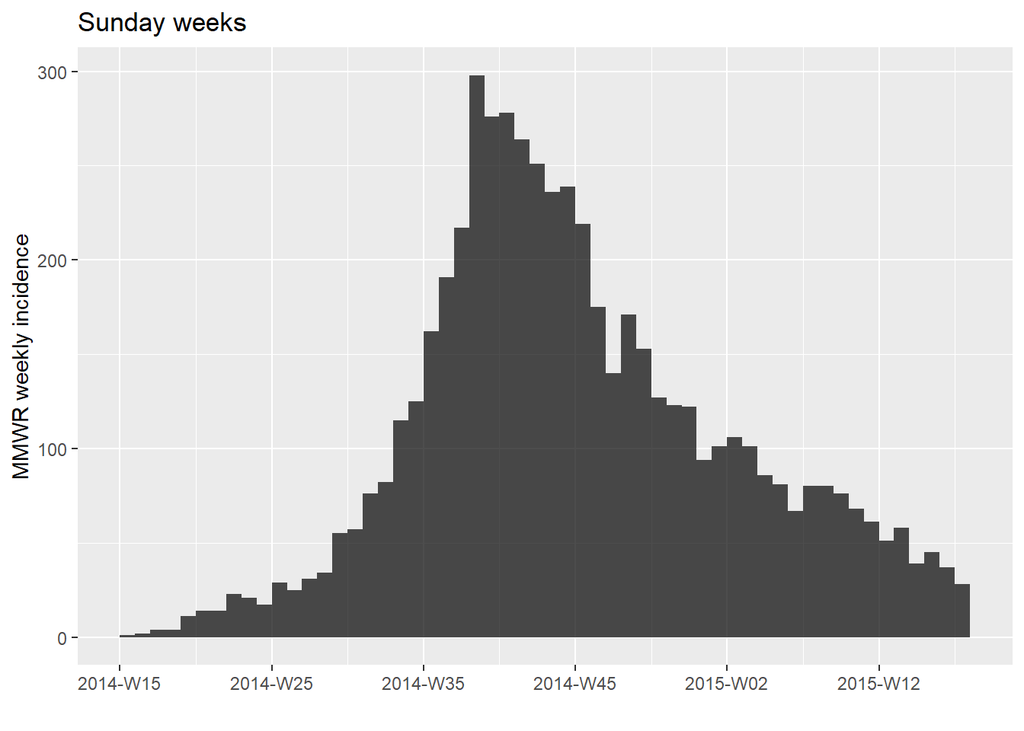

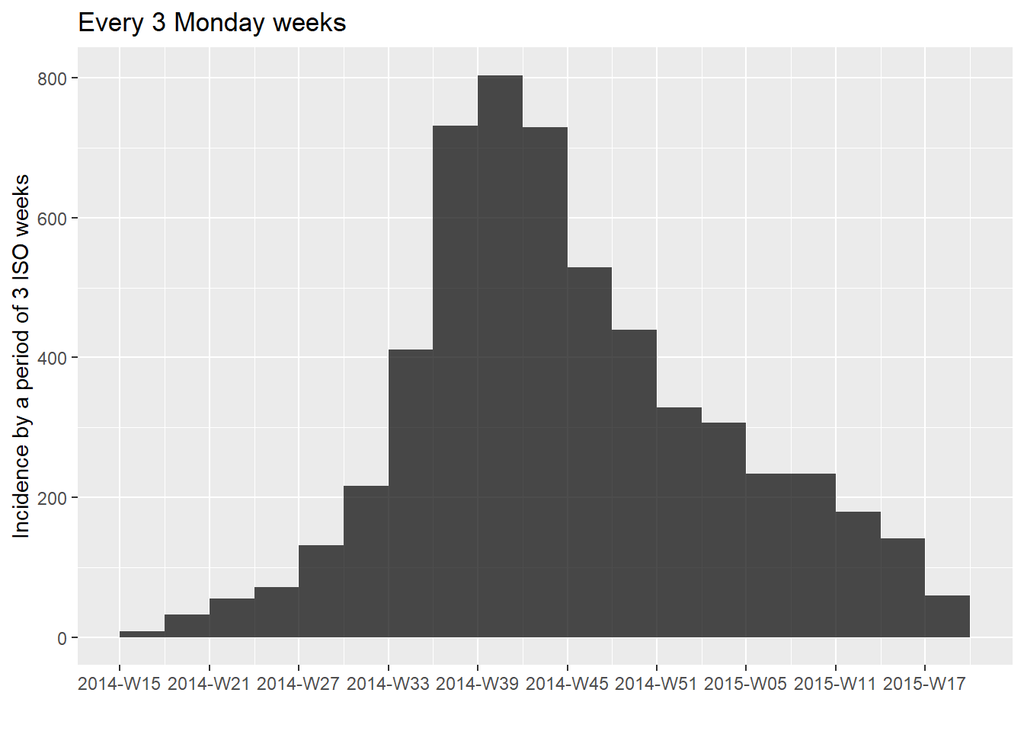

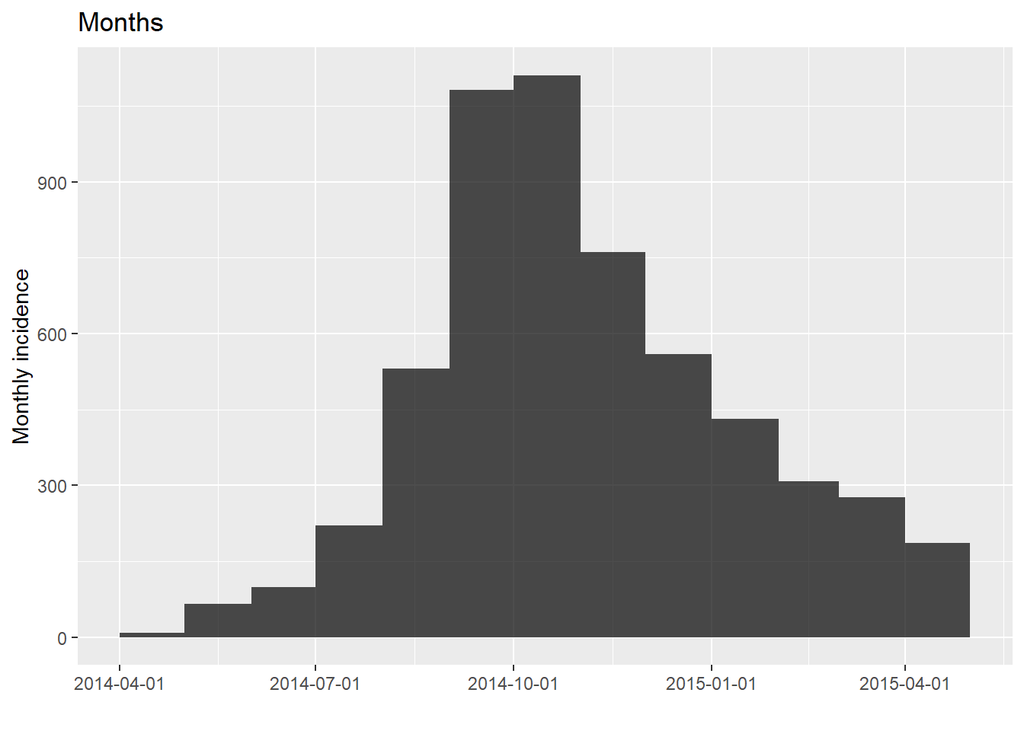

```r
# Plot the incidence objects (+ titles for clarity)
############################
plot(epi_wk)+     labs(title = "Monday weeks")
plot(epi_Sun_wk)+ labs(title = "Sunday weeks")
plot(epi_3wk)+    labs(title = "Every 3 Monday weeks")
plot(epi_month)+  labs(title = "Months")
```

### Modifications

The **incidence** package enables modifications in the following ways:

- Arguments of `plot()` (e.g. `show_cases`, `col_pal`, `alpha`…)
- `scale_x_incidence()` and `make_labels()`
- `ggplot()` additions via the `+` operator

Read details in the Help files by entering `?scale_x_incidence` and `?plot.incidence` in the R console. Online vignettes are listed in the resources tab.

#### `plot()` modifications

A incidence plot can be modified in the following ways. Type `?plot.incidence` in the R console for more details.

- `show_cases =` If TRUE, each case is shows as a box. Best on smaller outbreaks.
- `color =` Color of case bars/boxes
- `border =` Color of line around boxes, if `show_cases = TRUE`
- `alpha =` Transparency of case bars/boxes (1 is fully opaque, 0 is fully transparent)
- `xlab =` Title of x-axis (axis labels can also be applied using `labs()` from ggplot)
- `ylab =` Title of y-axis; defaults to user-defined incidence time interval
- `labels_week =` Logical, indicate whether x-axis labels are in week or date format, absent other modifications
- `n_breaks =` Number of x-axis label breaks, absent other modifications
- `first_date`, `last_date` Dates used to trim the plot

See examples of these arguments in the subsequent tabs.

#### Filtered data

**To plot the epicurve of a subset of data:**

1. Filter the linelist data
2. Feed the subset to the `incidence()` command

The example below uses data filtered to show only cases at Central Hospital.

```r
# filter the dataset
central_data <- linelist %>%
  filter(hospital == "Central Hospital")

# create incidence object using subset of data
central_outbreak <- incidence(central_data$date_onset, interval = "week")
```

```
## 15 missing observations were removed.
```

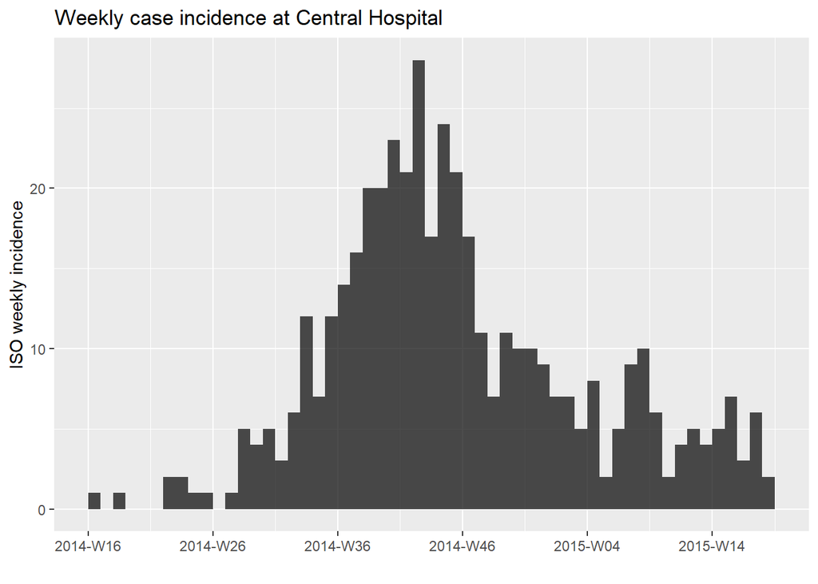

```r
# plot
plot(central_outbreak) + labs(title = "Weekly case incidence at Central Hospital")
```

#### Date-axis labels/gridlines

*TIP:* Remember that date-axis **labels** are independent from the aggregation of the data into bars

**Modify the bars**  
The aggregation of data into bars occurs when you set the `interval =` when creating the incidence object. The options for `interval` come from the package **aweek** and include options like “day”, “Monday week”, “Sunday week”, “month”, “2 weeks”, etc. See the incidence intro tab for more information.

**Modify date-axis labels (frequency & format)**

*DANGER:* Be cautious setting the y-axis scale breaks (e.g. 0 to 30 by 5: `seq(0, 30, 5)`). Static numbers can cut-off your data if the data changes!.

##### Option 1: `scale_x_incidence()` only

1. Add `scale_x_incidence()` from the **incidence** package:
   - Why use this approach?
     - **Advantages**: Short code. Auto-adjusts weekly labels to interval of incidence object (Monday, Sunday weeks, etc.)
     - **Disadvantages**: Cannot make fine adjustments to label format or minor vertical gridlines between labels
   - Provide the name of the incidence object to ensure labels align with specified `interval` (e.g. Sundays or Mondays)
   - *optional:* `n_breaks` specify number of date labels, which start from the *interval* of the first case.
     - for breaks every nth week, use `n_breaks = nrow(i)/n` (“i” is the incidence object name and “n” is a number)
   - *optional:* `labels_week` labels formatted as either weeks (YYYY-Www) or dates (YYYY-MM-DD)
   - One vertical gridline will appear per date label

Other notes:

```r
# create weekly incidence object (Sunday weeks)
i <- incidence(central_data$date_onset, interval = "Sunday week")
```

```
## 15 missing observations were removed.
```

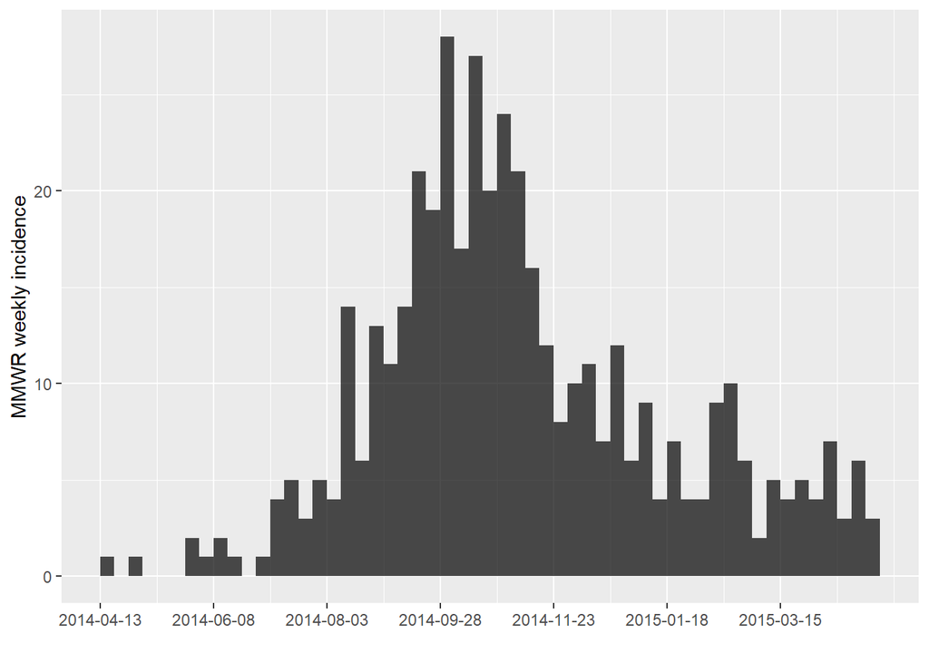

```r
plot(i)+
  scale_x_incidence(i,                    # name of incidence object
                    labels_week = F,      # show dates instead of weeks
                    n_breaks = nrow(i)/8) # breaks every 8 weeks from week of first case
```

##### Option 2: `scale_x_date()` and `make_breaks()`

2. Add `scale_x_date()` from **ggplot2**, but also leverage `make_breaks()` from **incidence**:
   - Why use this approach?
     - **Advantages**: Best of both worlds: weekly labels auto-aligned to incidence interval, *and* you can make detailed adjustments to label format
     - **Disadvantages**: *If* minor gridlines between Sunday-week date labels are desired, they are not auto-aligned
   - After creating the incidence object, use `make_breaks()` to define date label breaks
     - `make_breaks()` is similar to `scale_x_incidence()` (described above). Provide the incidence object name and optionally `n_breaks` as described before.
   - Add `scale_x_date()` to the plot:
     - `breaks =` provide the breaks vector you created with `make_breaks()`, followed by `$breaks` (see example below)
     - `date_labels =` provide a format for the date labels (e.g. “%d %b”) (use “” for new line)

```r
# Break modification using scale_x_date() and make_breaks()
###########################################################
# make incidence object
i <- incidence(central_data$date_onset, interval = "Monday week")
```

```
## 15 missing observations were removed.
```

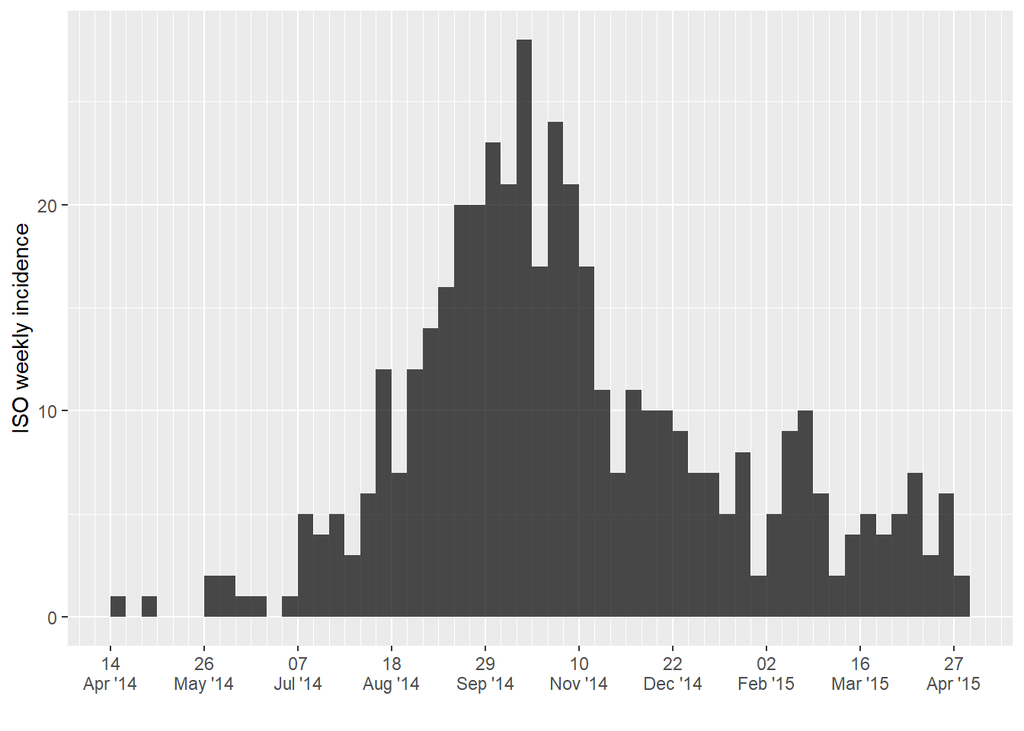

```r
# make breaks
i_labels <-  make_breaks(i, n_breaks = nrow(i)/6) # using interval from i, breaks every 6 weeks

# plot
plot(i)+
  scale_x_date(breaks      = i_labels$breaks, # call the breaks
               date_labels = "%d\n%b '%y",    # date format
               date_minor_breaks = "weeks")   # gridlines each week (aligns with Sundays only)
```

##### Option 3: Use `scale_x_date()` only

3. **Use `scale_x_date()` only**
   - **Advantages**: Complete control over breaks, labels, gridlines, and plot width
   - **Disadvantages**: More code required, more opportunity to make mistakes.
   - If your incidence *intervals* are days or **Monday weeks**, (easy!):
     - Provide interval to `date_breaks =` (e.g. “day”, “week”, “2 weeks”, “month”, “year”)
     - Provide interval to `date_minor_breaks =` for vertical lines between date labels
   - If your incidence *intervals* are **Sunday weeks**, it is more complex - see the tab for a Sunday week example
     - Provide a sequence of Sunday dates to `breaks =` and to `minor_breaks =`
   - Use `date_labels =` for formatting (see Dates page for tips)
   - Add the argument `expand = c(0,0)` to start labels at the first incidence bar. Otherwise, first label will shift depending on your specified label interval.

*Note: if using aggregated counts (for example an epiweek x-axis) your x-axis may not be Date class and may require use `scale_x_discrete()` instead of `scale_x_date()` - see ggplot tips page for more details.

```r
# Break modification using scale_x_date() only
##############################################
# make incidence object
i <- incidence(central_data$date_onset, interval = "Monday week")
```

```
## 15 missing observations were removed.
```

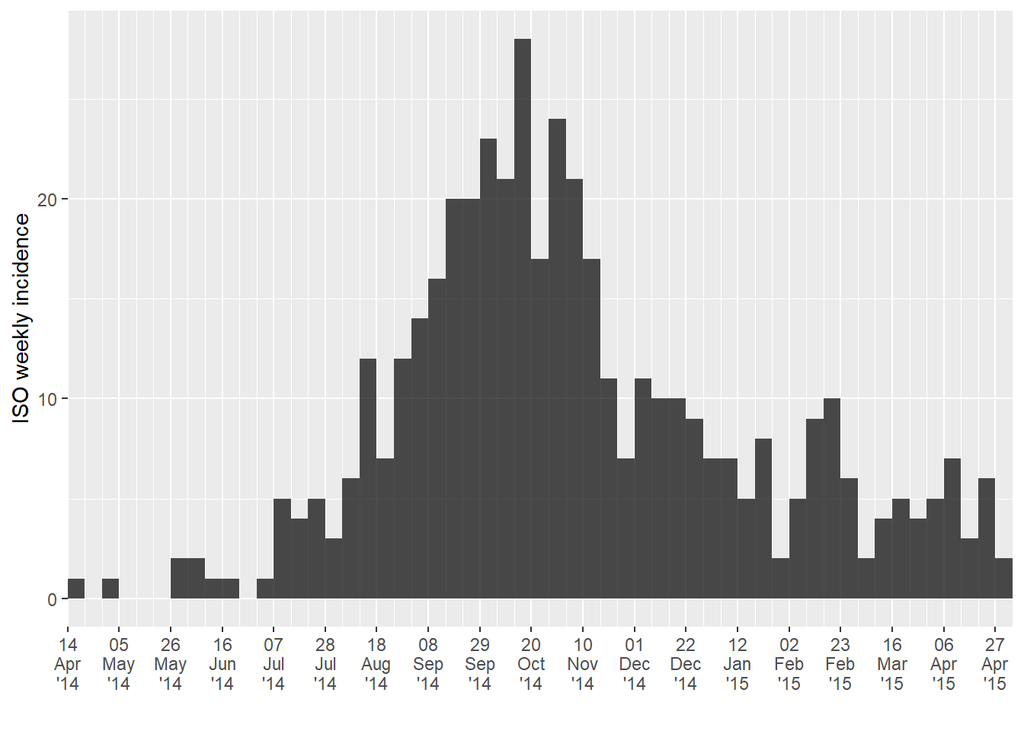

```r
# plot
plot(i)+
  scale_x_date(expand            = c(0,0),         # remove excess x-axis space below and after case bars
               date_breaks       = "3 weeks",      # labels appear every 3 Monday weeks
               date_minor_breaks = "week",         # vertical lines appear every Monday week
               date_labels       = "%d\n%b\n'%y")  # date labels format
```

##### A Sunday week example

If you want a plot of Sunday weeks and also finely-adjusted label formats, you might find a code example helpful.  
Here is an example of producing a weekly epicurve using **incidence** for Sunday weeks, with finely-adjusted date labels through `scale_x_date()`:

```r
# load packages
pacman::p_load(tidyverse,  # for ggplot
               incidence,  # for epicurve
               lubridate)  # for floor_date() and ceiling_date()

# create incidence object (specifying SUNDAY weeks)
central_outbreak <- incidence(central_data$date_onset, interval = "Sunday week") # equivalent to "MMWRweek" (see US CDC)
```

```
## 15 missing observations were removed.
```

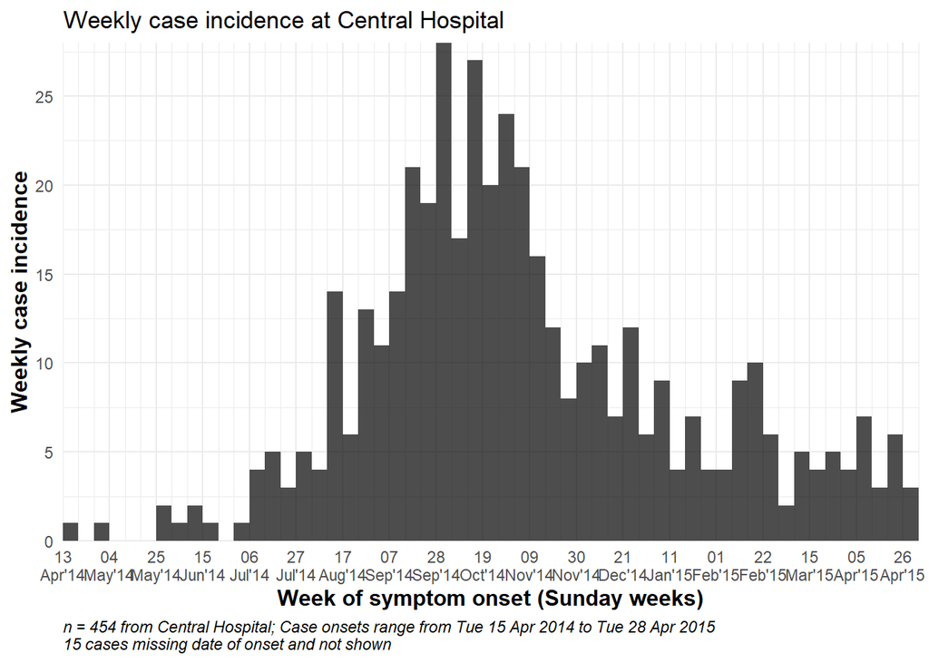

```r
# plot() the incidence object
plot(central_outbreak)+

  ### ggplot() commands added to the plot
  # scale modifications
  scale_x_date(
    expand = c(0,0),                 # remove excess x-axis space below and after case bars

    # sequence by 3 weeks, from Sunday before first case to Sunday after last case
    breaks = seq.Date(from = as.Date(floor_date(min(central_data$date_onset, na.rm=T),   "week", week_start = 7)),
                      to   = as.Date(ceiling_date(max(central_data$date_onset, na.rm=T), "week", week_start = 7)),
                      by   = "3 weeks"),

    # sequence by week, from Sunday before first case to Sunday after last case
    minor_breaks = seq.Date(from = as.Date(floor_date(min(central_data$date_onset, na.rm=T),   "week", week_start = 7)),
                            to   = as.Date(ceiling_date(max(central_data$date_onset, na.rm=T), "week", week_start = 7)),
                            by   = "7 days"),
    # date labels
    date_labels = "%d\n%b'%y")+       # adjust how dates are displayed

  scale_y_continuous(
    expand = c(0,0),                  # remove excess space under x-axis
    breaks = seq(0, 30, 5))+          # adjust y-axis intervals

  # Aesthetic themes
  theme_minimal()+                    # simplify background
  theme(
    axis.title = element_text(size = 12, face = "bold"),       # axis titles formatting
    plot.caption = element_text(face = "italic", hjust = 0))+  # caption formatting, left-aligned

  # Plot labels
  labs(x = "Week of symptom onset (Sunday weeks)",
       y = "Weekly case incidence",
       title = "Weekly case incidence at Central Hospital",
       #subtitle = "",
       caption  = stringr::str_glue("n = {nrow(central_data)} from Central Hospital; Case onsets range from {format(min(central_data$date_onset, na.rm=T), format = '%a %d %b %Y')} to {format(max(central_data$date_onset, na.rm=T), format = '%a %d %b %Y')}\n{nrow(central_data %>% filter(is.na(date_onset)))} cases missing date of onset and not shown"))
```

#### Show individual cases

**To show boxes around each individual case, use the argument `show_cases = TRUE` in the `plot()` function.**

Boxes around each case can be more reader-friendly, if the outbreak is of a small size. Boxes can be applied when the interval is days, weeks, or any other time period. The code below creates the *weekly* epicurve for a smaller outbreak (only cases from Central Hospital), with boxes around each case.

```r
# create filtered dataset for Central Hospital
central_data  <- linelist %>%
  filter(hospital == "Central Hospital")

# create incidence object (weekly)
central_outbreak <- incidence(central_data$date_onset, interval = "Monday week")
```

```
## 15 missing observations were removed.
```

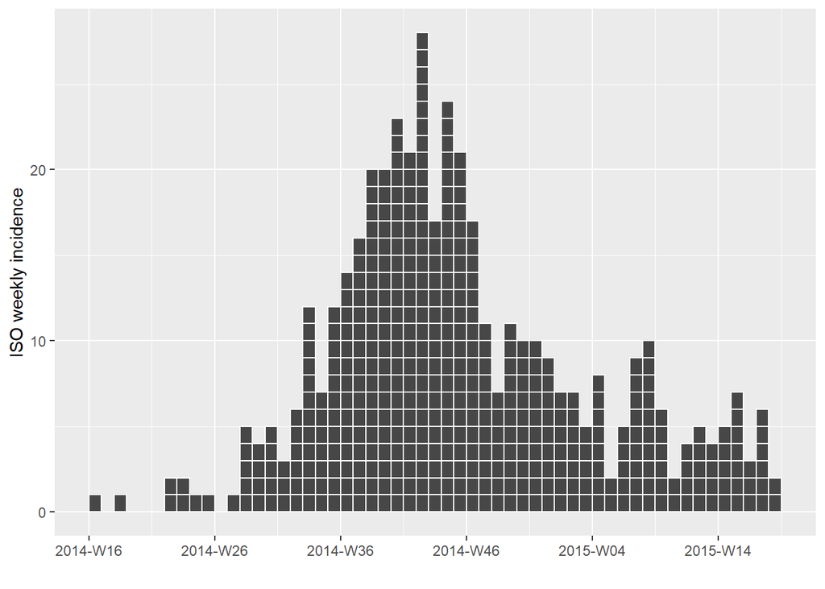

```r
# plot outbreak
plot(central_outbreak,
     show_cases = T)                 # show boxes around individual cases
```

The same epicurve showing individual cases, but with other aesthetic modifications:

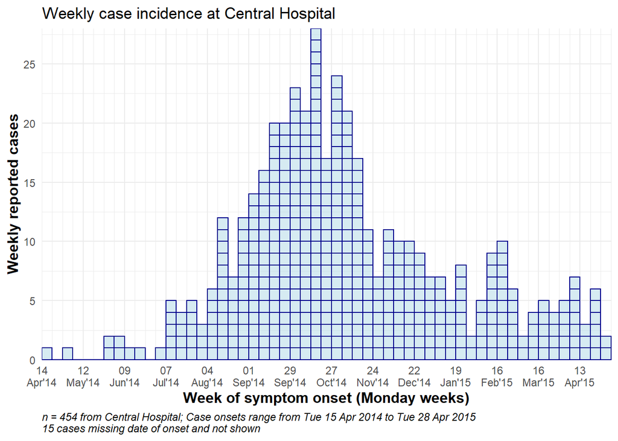

```r
# add plot() arguments and ggplot() commands
plot(central_outbreak,
     show_cases = T,                 # show boxes around each individual case
     color = "lightblue",            # color inside boxes
     border = "darkblue",            # color of border around boxes
     alpha = 0.5)+                    # transparency

  ### ggplot() commands added to the plot
  # scale modifications
  scale_x_date(
    expand            = c(0,0),         # remove excess x-axis space below and after case bars
    date_breaks       = "4 weeks",      # labels appear every 4 Monday weeks
    date_minor_breaks = "week",         # vertical lines appear every Monday week
    date_labels       = "%d\n%b'%y")+   # date labels format

  scale_y_continuous(
    expand = c(0,0),              # remove excess space under x-axis
    breaks = seq(0, 35, 5))+      # adjust y-axis intervals

  # aesthetic themes
  theme_minimal()+                                                 # simplify background

  theme(
    axis.title = element_text(size = 12, face = "bold"),       # axis title format
    plot.caption = element_text(face = "italic", hjust = 0))+  # caption format and left-align

  # plot labels
  labs(x = "Week of symptom onset (Monday weeks)",
       y = "Weekly reported cases",
       title = "Weekly case incidence at Central Hospital",
       #subtitle = "",
       caption  = stringr::str_glue("n = {nrow(central_data)} from Central Hospital; Case onsets range from {format(min(central_data$date_onset, na.rm=T), format = '%a %d %b %Y')} to {format(max(central_data$date_onset, na.rm=T), format = '%a %d %b %Y')}\n{nrow(central_data %>% filter(is.na(date_onset)))} cases missing date of onset and not shown"))
```

#### Color by value

To color the cases by value, provide the column to the `groups =` argument in the `incidence()` command. In the example below the cases are colored by their age category. Note the use of `incidence()` argument `na_as_group =`. If TRUE (by default) missing values (`NA`) will form their own group.

```r
# Create incidence object, with data grouped by age category
age_outbreak <- incidence(linelist$date_onset,            # date of onset for x-axis
                               interval = "week",         # weekly aggregation of cases
                               groups = linelist$age_cat, # color by age_cat value
                               na_as_group = TRUE)        # missing values assigned their own group
```

```
## 248 missing observations were removed.
```

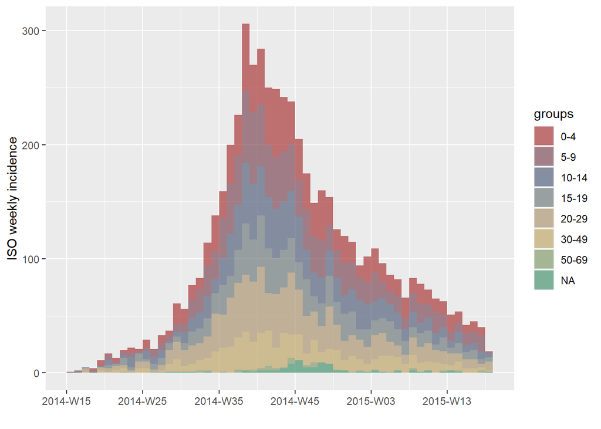

```r
# plot the epicurve
plot(age_outbreak)
```

**Adjusting order**

To adjust the order of group appearance (on plot and in legend), the group column must be class Factor. Adjust the order by adjusting the order of the levels (including `NA`). Below is an example with gender groups using data from Central Hospital only.

- First, the dataset is defined and gender is re-defined as a factor
- The order of levels of gender are defined with `NA` first, so it appears on the top of the bars
- More appropriate labels are defined for each factor level - these appear in the legend
- The argument `exclude = NULL` in `factor()` is necessary to adjust the order of `NA`, which is excluded by default.
- Title of legend adjusted using `fill =` in `labs()`

You can read more about factors in their page (LINK)

```r
# Create incidence object, data grouped by gender
#################################################

# Classify "gender" column as factor
####################################
# with specific level order and labels, includin for missing values
central_data <- linelist %>%
  filter(hospital == "Central Hospital") %>%
  mutate(gender = factor(gender,
                         levels = c(NA, "f", "m"),
                         labels = c("Missing", "Female", "Male"),
                         exclude = NULL))

# Create incidence object, by gender
####################################
gender_outbreak_central <- incidence(central_data$date_onset,
                                     interval = "week",
                                     groups = central_data$gender,
                                     na_as_group = TRUE)   # Missing values assigned their own group
```

```
## 15 missing observations were removed.
```

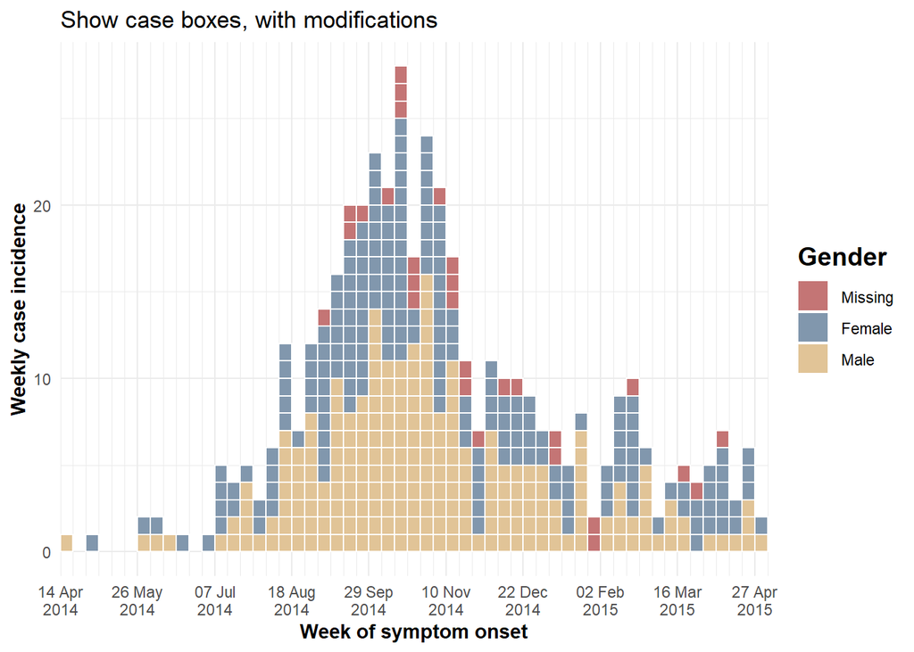

```r
# plot epicurve with modifications
##################################
plot(gender_outbreak_central,
     show_cases = TRUE)+                            # show box around each case

     ### ggplot commands added to plot
     # scale modifications
     scale_x_date(expand = c(0,0),
                  date_breaks = "6 weeks",
                  date_minor_breaks = "week",
                  date_labels = "%d %b\n%Y")+

     # aesthetic themes
     theme_minimal()+                               # simplify plot background
     theme(
       legend.title = element_text(size = 14, face = "bold"),
       axis.title = element_text(face = "bold"))+   # axis title bold

      # plot labels
      labs(fill = "Gender",                         # title of legend
           title = "Show case boxes, with modifications",
           y = "Weekly case incidence",
           x = "Week of symptom onset")
```

#### Change colors and legend

**To change the legend**  
Use `ggplot()` commands such as:

- `theme(legend.position = "top")` (or “bottom”, “left”, “right”)
- `theme(legend.direction = "horizontal")`
- `theme(legend.title = element_blank())` to have no title

See the page of ggplot() tips for more details on legends.

**To specify colors manually**, provide the name of the color or a character vector of multiple colors to the argument `color =`. Note to function properly the number of colors listed must equal the number of groups (be aware of missing values as a group)

```r
# weekly outbreak by hospital
hosp_outbreak <- incidence(linelist$date_onset,
                               interval = "week",
                               groups = linelist$hospital,
                               na_as_group = FALSE)   # Missing values not assigned their own group
```

```
## 248 missing observations were removed.
```

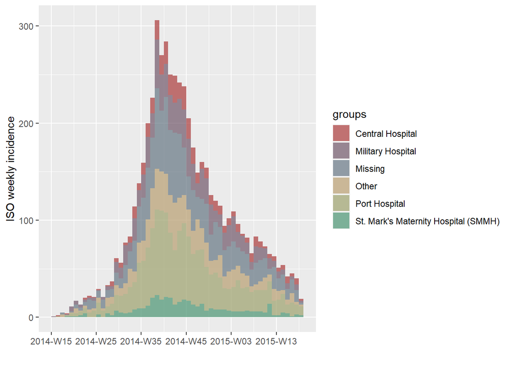

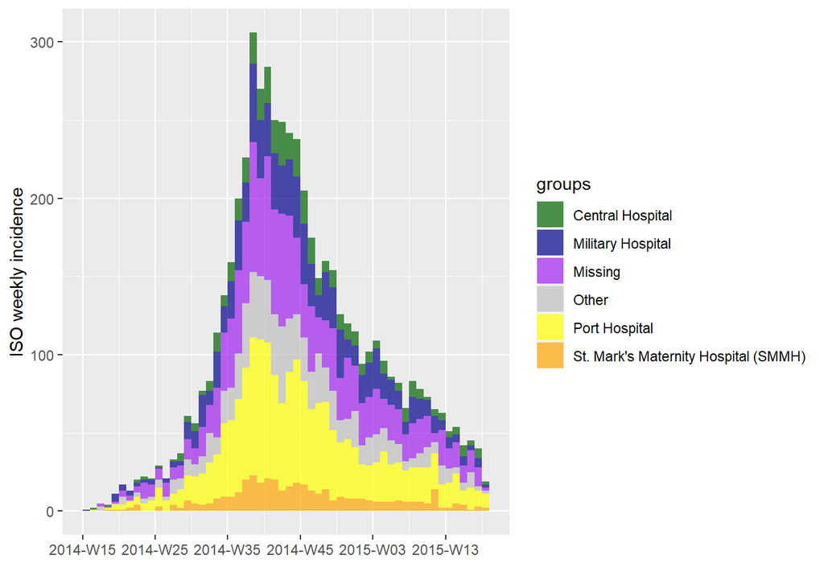

```r
# default colors
plot(hosp_outbreak)

# manual colors
plot(hosp_outbreak, color = c("darkgreen", "darkblue", "purple", "grey", "yellow", "orange"))
```

**To change the color palette**  
Use the argument `col_pal` in `plot()` to change the color palette to one of the default **base** R palettes (do *not* put the name of the palette in quotes).

```r
# Create incidence object, with data grouped by age category
age_outbreak <- incidence(linelist$date_onset,            # date of onset for x-axis
                               interval = "week",         # weekly aggregation of cases
                               groups = linelist$age_cat, # color by age_cat value
                               na_as_group = TRUE)        # missing values assigned their own group
```

```
## 248 missing observations were removed.
```

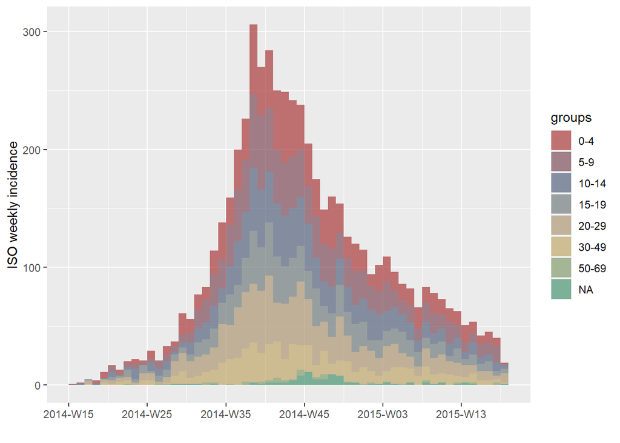

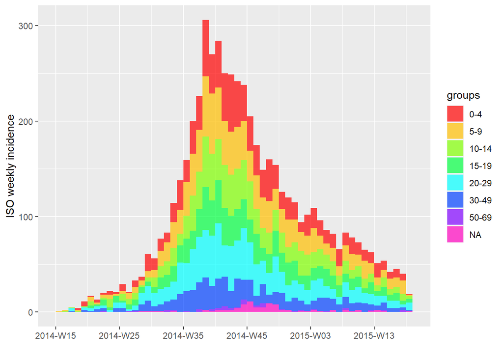

```r
# plot the epicurve
plot(age_outbreak)

# plot with different color palette
plot(age_outbreak, col_pal = rainbow)
```

#### Facets/small multiples

To facet the plot by a variable (make “small multiples”), see the tab on epicurves with `ggplot()`

## `ggplot()`

Below are tabs on using the **ggplot2** package to produce epicurves from a linelist dataset.

Unlike using **incidence** package, you must manually control the aggregation of the data (into weeks, months, etc) *and* the labels on the date axis. If not carefully managed, this can lead to many headaches.

These tabs use a subset of the `linelist` dataset - only the cases from Central Hospital.

```r
central_data <- linelist %>%
  filter(hospital == "Central Hospital")
```

```r
detach("package:tidyverse", unload=TRUE)
library(tidyverse)
```

### Intro

To produce an epicurve with `ggplot()` there are three main elements:

- A histogram, to aggregate the linelisted cases into “bins” and display bars of the counts per bin (potentially by grouped values)
- Scales for the axes and their associated labels (see tab on modifications)
- Aesthetic themes for the plot, including titles, labels, captions, etc.

Below is perhaps the most simple code to produce daily and weekly epicurves. Axis scales and labels use default options.

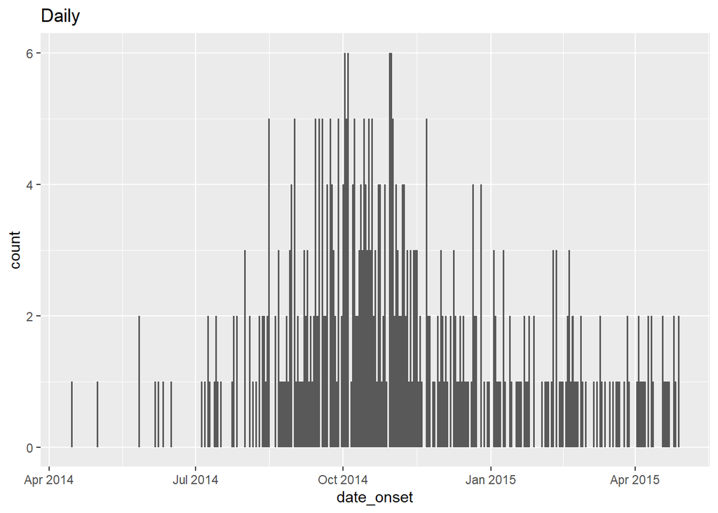

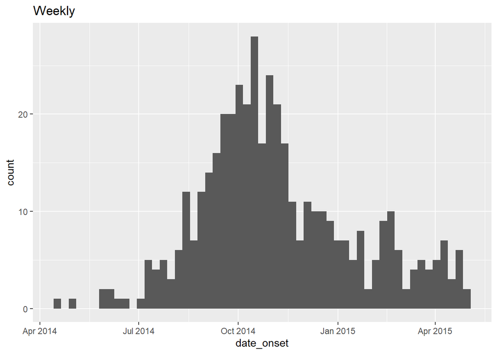

```r
# daily
ggplot(data = central_data, aes(x = date_onset)) +  # x column must be class Date
  geom_histogram(binwidth = 1)+                     # date values binned by 1 day
  labs(title = "Daily")
# weekly
ggplot(data = central_data, aes(x = date_onset)) +
  geom_histogram(binwidth = 7)+                     # date values binned each 7 days (arbitrary 7 days!)
  labs(title = "Weekly")
```

*CAUTION:* Using `binwidth = 7` starts the first bin at the first case, which could be any day of the week! To create specific Monday or Sunday weeks, see below .

To create weekly epicurves where the bins begin on a specific day of the week (e.g. Monday, Sunday), specify the histogram `breaks =` manually (not `binwidth`). This can be done by creating a sequence of dates using `seq.Date()` from **base** R. You can start/end the sequence at a specific date (`as.Date("YYYY-MM-DD")`, or write flexible code to begin the sequence at a specific day of the week before the first case. An example of creating such weekly breaks is below:

```r
seq.Date(from = as.Date(floor_date(min(central_data$date_onset, na.rm=T),   "week", week_start = 1)),
         to   = as.Date(ceiling_date(max(central_data$date_onset, na.rm=T), "week", week_start = 1)),
         by   = "7 days")
```

To achieve the “from” value (earliest date of the sequence), the minimum value in the column `date_onset` is fed to `floor_date()` from the **lubridate** package, which according to the above specified arguments produces the start date of that “week”, given that the start of each week is a Monday (`week_start = 1`). Likewise, the “to” value (end date of the sequence) is specified using the inverse `ceiling_date()` function to produce the Monday *after* the last case. The “by” argument can be set to any length of days, weeks, or months.

This code is applied to create the histogram breaks, and also the breaks for the date labels. Read more about the date labels in the Modifications tab. Defining your breaks like above will be necessary if your weekly bins are not by Monday weeks.

Below is detailed code to produce weekly epicurves for Monday and Sunday weeks. See the tab on Modifications (axes) to learn the nuances of date-axis label management.

**Monday weeks**

Of note:

- The break points of the *histogram bins* are specified manually to begin the Monday (`week_start = 1`) before the earliest case and to end the Monday after the last case (see explanation above).
- The breaks for *date labels* on x-axis - because the bins are Monday weeks this code uses `date_breaks =` within `scale_x_date()`, which also uses Monday weeks. Sunday weeks use a different method.
- Minor vertical gridlines between date labels are made using `date_minor_breaks =` within `scale_x_date()`, again because this plot is for Monday weeks. Sunday weeks use a different method.
- Adding `expand = c(0,0)` to the x and y scales removes excess space on each side of the plot, which also ensures the labels begin at the first bar.
- Color and fill are defined in `geom_histogram()`

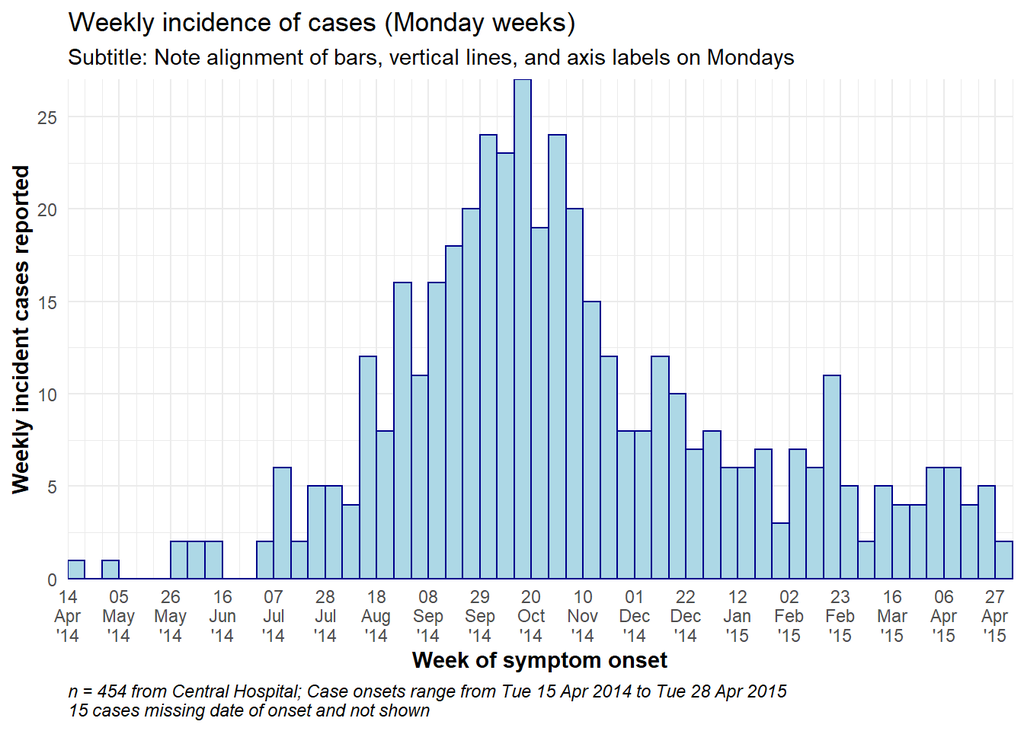

```r
# TOTAL MONDAY WEEK ALIGNMENT
#############################
ggplot(central_data, aes(x = date_onset)) +
  # make histogram: specify bin break points: starts the Monday before first case, end Monday after last case
  geom_histogram(
    breaks = seq.Date(from = as.Date(floor_date(min(central_data$date_onset, na.rm=T),   "week", week_start = 1)),
                      to   = as.Date(ceiling_date(max(central_data$date_onset, na.rm=T), "week", week_start = 1)),
                      by   = "7 days"), # bins are 7-days
    color = "darkblue",   # color of lines around bars
    fill = "lightblue") + # color of fill within bars

  # x-axis labels
  scale_x_date(expand            = c(0,0),         # remove excess x-axis space below and after case bars
               date_breaks       = "3 weeks",      # labels appear every 3 Monday weeks
               date_minor_breaks = "week",         # vertical lines appear every Monday week
               date_labels       = "%d\n%b\n'%y")+ # date labels format

  # y-axis
  scale_y_continuous(expand = c(0,0))+             # remove excess y-axis space between bottom of bars and the labels

  # aesthetic themes
  theme_minimal()+                                               # a set of themes to simplify plot
  theme(plot.caption = element_text(face = "italic", hjust = 0), # caption on left side in italics
        axis.title = element_text(face = "bold"))+               # axis titles in bold

  # labels
  labs(title    = "Weekly incidence of cases (Monday weeks)",
       subtitle = "Subtitle: Note alignment of bars, vertical lines, and axis labels on Mondays",
       x        = "Week of symptom onset",
       y        = "Weekly incident cases reported",
       caption  = stringr::str_glue("n = {nrow(central_data)} from Central Hospital; Case onsets range from {format(min(central_data$date_onset, na.rm=T), format = '%a %d %b %Y')} to {format(max(central_data$date_onset, na.rm=T), format = '%a %d %b %Y')}\n{nrow(central_data %>% filter(is.na(date_onset)))} cases missing date of onset and not shown"))
```

**Sunday weeks**

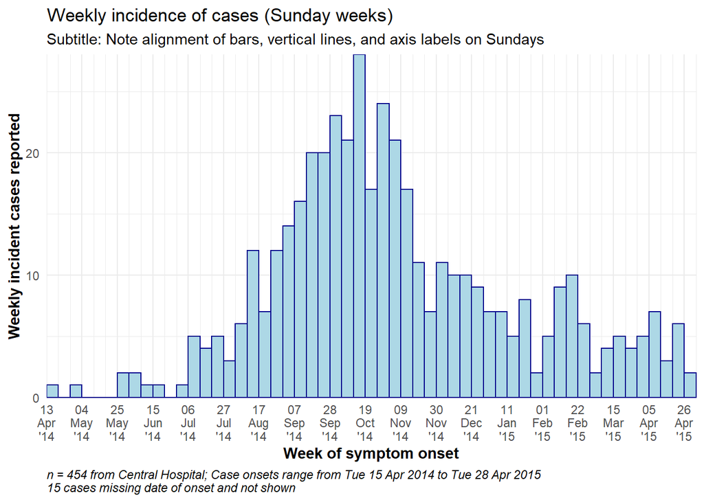

```r
# TOTAL SUNDAY WEEK ALIGNMENT
#############################
ggplot(central_data, aes(x = date_onset)) +

  # For histogram, manually specify bin break points: starts the Sunday before first case, end Sunday after last case
  geom_histogram(
    breaks = seq.Date(from = as.Date(floor_date(min(central_data$date_onset, na.rm=T),   "week", week_start = 7)),
                      to   = as.Date(ceiling_date(max(central_data$date_onset, na.rm=T), "week", week_start = 7)),
                      by   = "7 days"), # bins are 7-days
    color = "darkblue",   # color of lines around bars
    fill = "lightblue") + # color of fill within bars

  # The labels on the x-axis
  scale_x_date(expand = c(0,0),
               breaks = seq.Date(from = as.Date(floor_date(min(central_data$date_onset, na.rm=T),   "week", week_start = 7)),
                                 to   = as.Date(ceiling_date(max(central_data$date_onset, na.rm=T), "week", week_start = 7)),
                                 by   = "3 weeks"),
               minor_breaks = seq.Date(from = as.Date(floor_date(min(central_data$date_onset, na.rm=T),   "week", week_start = 7)),
                                       to   = as.Date(ceiling_date(max(central_data$date_onset, na.rm=T), "week", week_start = 7)),
                                       by   = "7 days"),
               date_labels = "%d\n%b\n'%y")+             # day, above month abbrev., above 2-digit year

  # y-axis
  scale_y_continuous(expand = c(0,0))+                   # removes excess y-axis space between bottom of bars and the labels

  # aesthetic themes
  theme_minimal()+                                               # a set of themes to simplify plot
  theme(plot.caption = element_text(face = "italic", hjust = 0), # caption on left side in italics
        axis.title = element_text(face = "bold"))+               # axis titles in bold

  # labels
  labs(title    = "Weekly incidence of cases (Sunday weeks)",
       subtitle = "Subtitle: Note alignment of bars, vertical lines, and axis labels on Sundays",
       x        = "Week of symptom onset",
       y        = "Weekly incident cases reported",
       caption  = stringr::str_glue("n = {nrow(central_data)} from Central Hospital; Case onsets range from {format(min(central_data$date_onset, na.rm=T), format = '%a %d %b %Y')} to {format(max(central_data$date_onset, na.rm=T), format = '%a %d %b %Y')}\n{nrow(central_data %>% filter(is.na(date_onset)))} cases missing date of onset and not shown"))
```

### Modifications

#### Modify axes

*TIP:* Remember that date-axis **labels** are independent from the aggregation of the data into bars

To **modify the aggregation of data into bins/bars**, do one of the following:

- Specify a `binwidth =` within `geom_histogram()` - for a column of class Date, the given number is interpreted in days
- Specify `breaks =` as a sequence of bin break-point dates
- Group the rows into aggregated counts (by week, month, etc.) and feed the aggregated counts to `ggplot()`. See the tab on aggregated counts for more information.

To **modify the date labels**, use `scale_x_date()` in one of these ways:

- If your histogram bins are days, Monday weeks, months, or years:
  - Use `date_breaks =` to specify label frequency (e.g. “day”, “week”, “3 weeks”, “month”, or “year”)
  - Use `date_minor_breaks =` to specify frequency of minor vertical gridlines between date labels
  - Add `expand = c(0,0)` to begin the labels at the first bar (otherwise, first label will shift forward depending on specified frequency)
  - Use `date_labels =` to specify format of date labels - see the Dates page for tips (use `\n` for a new line)
- If your histogram bins are Sunday weeks:
  - Use `breaks =` and `minor_breaks =` by providing a sequence of dates for breaks
  - You can still use `date_labels =` for formatting as described above

To **create a sequence of dates**  
You can use `seq.Date()` from **base** R. You can start/end the sequence at a specific date (`as.Date("YYYY-MM-DD")`, or write flexible code to begin the sequence at a specific day of the week before the first case. An example of creating such flexible breaks is below:

```r
seq.Date(from = as.Date(floor_date(min(central_data$date_onset, na.rm=T),   "week", week_start = 1)),
         to   = as.Date(ceiling_date(max(central_data$date_onset, na.rm=T), "week", week_start = 1)),
         by   = "7 days")
```

To achieve the “from” value (earliest date of the sequence), the minimum value in the column `date_onset` is fed to `floor_date()` from the **lubridate** package, which according to the above specified arguments produces the start date of that “week”, given that the start of each week is a Monday (`week_start = 1`). Likewise, the “to” value (end date of the sequence) is specified using the inverse `ceiling_date()` function to produce the Monday *after* the last case. The “by” argument can be set to any length of days, weeks, or months.

If using aggregated counts (for example an epiweek x-axis) your x-axis may not be Date class and may require use `scale_x_discrete()` instead of `scale_x_date()` - see ggplot tips page for more details.

Set maximum and minimum date values using `limits = c()` within `scale_x_date()`. E.g. `scale_x_date(limits = c(as.Date("2014-04-01), NA))` sets a minimum but leaves the maximum open.

*CAUTION:* Caution using limits! They remove all data outside the limits, which can impact y-axis max/min, modeling, and other statistics. Strongly consider instead using limits by adding `coord_cartesian()` to your plot, which acts as a “zoom” without removing data.

*DANGER:* Be cautious setting the y-axis scale breaks (e.g. 0 to 30 by 5: `seq(0, 30, 5)`). Static numbers can cut-off your data if the data changes!.

https://rdrr.io/r/base/strptime.html —– see all % shortcuts

**Below is a demonstration of some plots where the bins and the plot labels/gridlines are aligned and not aligned:**  
Click “Code” to see the code

[figure not shown]

[figure not shown]

[figure not shown]

[figure not shown]

[figure not shown]

```r
# 7-day binwidth defaults
#################
ggplot(central_data, aes(x = date_onset)) + # x column must be class Date
  geom_histogram(
    binwidth = 7,                       # 7 days per bin (! starts at first case!)
    color = "darkblue",                 # color of lines around bars
    fill = "lightblue") +               # color of bar fill

  labs(
    title = "MISALIGNED",
    subtitle = "!CAUTION: 7-day bars start Thursdays with first case\ndefault axis labels/ticks not aligned")
# 7-day bins + Monday labels
#############################
ggplot(central_data, aes(x = date_onset)) +
  geom_histogram(
    binwidth = 7,                 # 7-day bins with start at first case
    color = "darkblue",
    fill = "lightblue") +

  scale_x_date(
    expand = c(0,0),               # remove excess x-axis space below and after case bars
    date_breaks = "3 weeks",       # Monday every 3 weeks
    date_minor_breaks = "week",    # Monday weeks
    date_labels = "%d\n%b\n'%y")+  # label format

  scale_y_continuous(
    expand = c(0,0))+              # remove excess space under x-axis, make flush with labels

  labs(
    title = "MISALIGNED",
    subtitle = "!CAUTION: 7-day bars start Thursdays with first case\nDate labels and gridlines on Mondays")
# 7-day bins + Months
#####################
ggplot(central_data, aes(x = date_onset)) +
  geom_histogram(
    binwidth = 7,
    color = "darkblue",
    fill = "lightblue") +

  scale_x_date(
    expand = c(0,0),                 # remove excess x-axis space below and after case bars
    date_breaks = "months",          # 1st of month
    date_minor_breaks = "week",      # Monday weeks
    date_labels = "%d\n%b\n'%y")+    # label format

  scale_y_continuous(
    expand = c(0,0))+                # remove excess space under x-axis, make flush with labels

  labs(
    title = "MISALIGNED",
    subtitle = "!CAUTION: 7-day bars start Thursdays with first case\nGridlines at 1st of each month (with labels) and weekly on Mondays\nLabels on 1st of each month")
# TOTAL MONDAY ALIGNMENT: specify manual bin breaks to be mondays
#################################################################
ggplot(central_data, aes(x = date_onset)) +
  geom_histogram(
    # histogram breaks set to 7 days beginning Monday before first case
    breaks = seq.Date(
      from = as.Date(floor_date(min(central_data$date_onset, na.rm=T),   "week", week_start = 1)),
      to   = as.Date(ceiling_date(max(central_data$date_onset, na.rm=T), "week", week_start = 1)),
      by   = "7 days"),
    color = "darkblue",
    fill = "lightblue") +

  scale_x_date(
    expand = c(0,0),                   # remove excess x-axis space below and after case bars
    date_breaks = "3 weeks",           # Monday every 3 weeks
    date_minor_breaks = "week",        # Monday weeks
    date_labels = "%d\n%b\n'%y")+      # label format

  labs(
    title = "ALIGNED Mondays",
    subtitle = "7-day bins manually set to begin Monday before first case (28 Apr)\nDate labels and gridlines on Mondays as well")
# TOTAL SUNDAY ALIGNMENT: specify manual bin breaks AND labels to be Sundays
############################################################################
ggplot(central_data, aes(x = date_onset)) +
  geom_histogram(
    # histogram breaks set to 7 days beginning Sunday before first case
    breaks = seq.Date(from = as.Date(floor_date(min(central_data$date_onset, na.rm=T),   "week", week_start = 7)),
                      to   = as.Date(ceiling_date(max(central_data$date_onset, na.rm=T), "week", week_start = 7)),
                      by   = "7 days"),
    color = "darkblue",
    fill = "lightblue") +

  scale_x_date(
    expand = c(0,0),
    # date label breaks set to every 3 weeks beginning Sunday before first case
    breaks = seq.Date(from = as.Date(floor_date(min(central_data$date_onset, na.rm=T),   "week", week_start = 7)),
                      to   = as.Date(ceiling_date(max(central_data$date_onset, na.rm=T), "week", week_start = 7)),
                      by   = "3 weeks"),
    # gridlines set to weekly beginning Sunday before first case
    minor_breaks = seq.Date(from = as.Date(floor_date(min(central_data$date_onset, na.rm=T),   "week", week_start = 7)),
                            to   = as.Date(ceiling_date(max(central_data$date_onset, na.rm=T), "week", week_start = 7)),
                            by   = "7 days"),
    date_labels = "%d\n%b\n'%y")+  # label format

  labs(title = "ALIGNED Sundays",
       subtitle = "7-day bins manually set to begin Sunday before first case (27 Apr)\nDate labels and gridlines manually set to Sundays as well")
# Check values of bars by creating dataframe of grouped values
# central_tab <- central_data %>%
#   mutate(week = aweek::date2week(date_onset, floor_day = TRUE, factor = TRUE)) %>%
#   group_by(week, .drop=F) %>%
#   summarize(n = n()) %>%
#   mutate(groups_3wk = 1:(nrow(central_tab)+1) %/% 3) %>%
#   group_by(groups_3wk) %>%
#   summarize(n = n())
```